# Fraud Analysis and Prediction

```python
import pandas as pd, numpy as np, matplotlib.pyplot as plt, seaborn as sns
```

```python
# To ignore all warnings
import warnings
warnings.filterwarnings("ignore")
```

```python
color_bluesets = {'lightblue':'#ADD8E6','skyblue':'#87CEEB','royalblue':'#4169E1','navyblue':'#000080','babyblue':'#89CFF0','turquoise':'#40E0D0','teal':'#008080','steelblue':'#4682B4','dodgerblue':'#1E90FF','cornflowerblue':'#6495ED','powderblue':'#B0E0E6','periwinkle':'#CCCCFF'}
```

```python
color_palette = sns.color_palette()
plt.style.use('ggplot')
%matplotlib inline
```

```python
df = pd.read_excel(r"C:\Users\Gee Oc\Documents\Credit_card_dataset.xlsx", sheet_name='dataset_')
```

```python
df
```

|  | AcountNumber | CVV | CardInformation | CustomerAge | Gender | Marital Status | Cards | CardColour | CardType | TransactionType | Domain | ATM | POSWEBLimit | CreditLimit | Amount | AverageIncomeExpendicture | NewBalance | OldBalance | Outcome |
| --- | --- | --- | --- | --- | --- | --- | --- | --- | --- | --- | --- | --- | --- | --- | --- | --- | --- | --- | --- |
| 0 | 1275734409 | 364 | 755189 | 28.0 | Male | Married | Debit | Gold | Verve | Credit | Local | 150000 | 2000000 | 500000 | 129282 | 170919 | 460070 | 330788 | 0 |
| 1 | 1271246193 | 401 | 513706 | 25.0 | Male | Single | Debit | Gold | Verve | Debit | International | 150000 | 2000000 | 200000 | 574384 | 329353 | 136286 | 327052 | 1 |
| 2 | 1242290165 | 266 | 648473 | 21.0 | Female | Married | Credit | White | Visa | Credit | International | 120000 | 4000000 | 500000 | 190766 | 292922 | 448997 | 258231 | 0 |
| 3 | 1245478185 | 402 | 416049 | 26.0 | Male | Unknown | Credit | White | Visa | Credit | Local | 120000 | 4000000 | 500000 | 130395 | 145444 | 330071 | 199676 | 0 |
| 4 | 1258212072 | 334 | 459937 | 28.0 | Female | Married | Debit | Gold | Verve | Credit | International | 150000 | 2000000 | 500000 | 685145 | 295990 | 991630 | 306485 | 1 |
| ... | ... | ... | ... | ... | ... | ... | ... | ... | ... | ... | ... | ... | ... | ... | ... | ... | ... | ... | ... |
| 37092 | 1250026389 | 637 | 546587 | 62.0 | Female | Married | Debit | Gold | Verve | Credit | Local | 150000 | 2000000 | 500000 | 534813 | 198167 | 794190 | 259377 | 1 |
| 37093 | 1247133695 | 582 | 734131 | 20.0 | Male | Divorced | Debit | Gold | Verve | Credit | Local | 150000 | 2000000 | 500000 | 178903 | 147133 | 468317 | 289414 | 0 |
| 37094 | 1260545996 | 571 | 347867 | 67.0 | Male | Married | Credit | White | Visa | Debit | International | 120000 | 4000000 | 150000 | 301594 | 256814 | 385770 | 598596 | 1 |
| 37095 | 1267917366 | 528 | 343123 | 58.0 | Female | Unknown | Debit | Gold | Verve | Credit | International | 150000 | 2000000 | 500000 | 212826 | 113439 | 635798 | 422972 | 0 |
| 37096 | 1252870437 | 659 | 381300 | 27.0 | Male | Married | Credit | White | Visa | Credit | International | 120000 | 4000000 | 500000 | 133810 | 271388 | 725806 | 591996 | 0 |

37097 rows × 19 columns

```python
df.shape
```

```
(37097, 19)
```

```python
df.columns
```

```
Index(['AcountNumber', 'CVV', 'CardInformation', 'CustomerAge', 'Gender',
       'Marital Status', 'Cards', 'CardColour', 'CardType', 'TransactionType',
       'Domain', 'ATM', 'POSWEBLimit', 'CreditLimit', 'Amount',
       'AverageIncomeExpendicture', 'NewBalance', 'OldBalance', 'Outcome'],
      dtype='object')
```

```python
df[['CustomerAge','CreditLimit', 'Amount','AverageIncomeExpendicture', 'NewBalance', 'OldBalance']].describe()
```

|  | CustomerAge | CreditLimit | Amount | AverageIncomeExpendicture | NewBalance | OldBalance |
| --- | --- | --- | --- | --- | --- | --- |
| count | 28246.000000 | 37097.000000 | 37097.000000 | 37097.000000 | 3.709700e+04 | 37097.000000 |
| mean | 39.157509 | 335101.221123 | 550260.997736 | 227386.956492 | 2.948066e+05 | 350202.783028 |
| std | 20.063996 | 169488.715096 | 260629.814049 | 78977.053916 | 6.239614e+05 | 144781.945405 |
| min | 18.000000 | 150000.000000 | 100003.000000 | 100017.000000 | -8.973780e+05 | 100001.000000 |
| 25% | 23.000000 | 200000.000000 | 324480.000000 | 161178.000000 | -2.398140e+05 | 224577.000000 |
| 50% | 29.000000 | 200000.000000 | 550293.000000 | 222530.000000 | 2.154320e+05 | 348916.000000 |
| 75% | 55.000000 | 500000.000000 | 775075.000000 | 283447.000000 | 8.509920e+05 | 477291.000000 |
| max | 85.000000 | 600000.000000 | 999956.000000 | 399971.000000 | 1.591355e+06 | 599990.000000 |

```python
df.info()
```

```
<class 'pandas.core.frame.DataFrame'>
RangeIndex: 37097 entries, 0 to 37096
Data columns (total 19 columns):
 #   Column                     Non-Null Count  Dtype
---  ------                     --------------  -----
 0   AcountNumber               37097 non-null  int64
 1   CVV                        37097 non-null  int64
 2   CardInformation            37097 non-null  int64
 3   CustomerAge                28246 non-null  float64
 4   Gender                     37097 non-null  object
 5   Marital Status             37097 non-null  object
 6   Cards                      37097 non-null  object
 7   CardColour                 37097 non-null  object
 8   CardType                   37097 non-null  object
 9   TransactionType            37097 non-null  object
 10  Domain                     37097 non-null  object
 11  ATM                        37097 non-null  int64
 12  POSWEBLimit                37097 non-null  int64
 13  CreditLimit                37097 non-null  int64
 14  Amount                     37097 non-null  int64
 15  AverageIncomeExpendicture  37097 non-null  int64
 16  NewBalance                 37097 non-null  int64
 17  OldBalance                 37097 non-null  int64
 18  Outcome                    37097 non-null  int64
dtypes: float64(1), int64(11), object(7)
memory usage: 5.4+ MB
```

```python
df.dtypes
```

```
AcountNumber                   int64
CVV                            int64
CardInformation                int64
CustomerAge                  float64
Gender                        object
Marital Status                object
Cards                         object
CardColour                    object
CardType                      object
TransactionType               object
Domain                        object
ATM                            int64
POSWEBLimit                    int64
CreditLimit                    int64
Amount                         int64
AverageIncomeExpendicture      int64
NewBalance                     int64
OldBalance                     int64
Outcome                        int64
dtype: object
```

```python
df.isna().values.any()
```

```
True
```

```python
df.isnull().sum()
```

```
AcountNumber                    0
CVV                             0
CardInformation                 0
CustomerAge                  8851
Gender                          0
Marital Status                  0
Cards                           0
CardColour                      0
CardType                        0
TransactionType                 0
Domain                          0
ATM                             0
POSWEBLimit                     0
CreditLimit                     0
Amount                          0
AverageIncomeExpendicture       0
NewBalance                      0
OldBalance                      0
Outcome                         0
dtype: int64
```

```python
# Get the index containing NaN
df.loc[df.isna().any(axis=1)].index
```

```
Index([12587, 12588, 12589, 12590, 12591, 12592, 12593, 12594, 12595, 12596,
       ...
       37067, 37068, 37069, 37070, 37071, 37072, 37073, 37074, 37075, 37076],
      dtype='int64', length=8851)
```

```python
# Get the Df containing NaN
df.loc[df.isna().any(axis=1)]
```

|  | AcountNumber | CVV | CardInformation | CustomerAge | Gender | Marital Status | Cards | CardColour | CardType | TransactionType | Domain | ATM | POSWEBLimit | CreditLimit | Amount | AverageIncomeExpendicture | NewBalance | OldBalance | Outcome |
| --- | --- | --- | --- | --- | --- | --- | --- | --- | --- | --- | --- | --- | --- | --- | --- | --- | --- | --- | --- |
| 12587 | 1258219644 | 288 | 776957 | NaN | Male | Married | Debit | Gold | Verve | Debit | International | 150000 | 2000000 | 200000 | 871613 | 256293 | -27470 | 142065 | 1 |
| 12588 | 1272351910 | 615 | 648337 | NaN | Female | Single | Debit | Gold | Verve | Debit | International | 150000 | 2000000 | 200000 | 169535 | 306866 | -135438 | 197081 | 0 |
| 12589 | 1262274079 | 488 | 574207 | NaN | Male | Married | Debit | Gold | Verve | Credit | Local | 150000 | 2000000 | 500000 | 332519 | 100672 | 611338 | 278819 | 0 |
| 12590 | 1257559104 | 317 | 782937 | NaN | Male | Unknown | Debit | Gold | Verve | Debit | International | 150000 | 2000000 | 200000 | 146306 | 393473 | -606440 | 389528 | 0 |
| 12591 | 1256782312 | 501 | 595566 | NaN | Female | Married | Credit | White | Visa | Debit | International | 120000 | 4000000 | 150000 | 995968 | 373724 | -255526 | 298618 | 1 |
| ... | ... | ... | ... | ... | ... | ... | ... | ... | ... | ... | ... | ... | ... | ... | ... | ... | ... | ... | ... |
| 37072 | 1287168037 | 240 | 498754 | NaN | Male | Single | Debit | Gold | Verve | Debit | Local | 150000 | 2000000 | 200000 | 433893 | 366862 | -165197 | 396018 | 1 |
| 37073 | 1281749838 | 668 | 363794 | NaN | Male | Single | Debit | Gold | Verve | Debit | International | 150000 | 2000000 | 200000 | 561215 | 134560 | 333208 | 594561 | 1 |
| 37074 | 1275644170 | 245 | 453448 | NaN | Female | Married | Credit | White | Visa | Debit | International | 120000 | 4000000 | 150000 | 261353 | 288790 | -516440 | 180789 | 1 |
| 37075 | 1263866116 | 523 | 337880 | NaN | Male | Single | Credit | White | Visa | Credit | Local | 120000 | 4000000 | 500000 | 697229 | 286482 | 1221839 | 524610 | 1 |
| 37076 | 1256723221 | 289 | 583447 | NaN | Female | Divorced | Debit | Gold | Verve | Debit | International | 150000 | 2000000 | 200000 | 685654 | 228658 | -64137 | 151678 | 1 |

8851 rows × 19 columns

```python
df['CustomerAge'].mean()
```

```
39.15750902782695
```

```python
# Fill null values on CustomerAge column
df['CustomerAge'].fillna(df['CustomerAge'].mean(), inplace=True)
```

```python
df['CustomerAge'] = df['CustomerAge'].astype(int)
```

##### Exploratory Analysis

1. **Demographic Analysis:**
- What is the distribution of customer ages in the dataset?

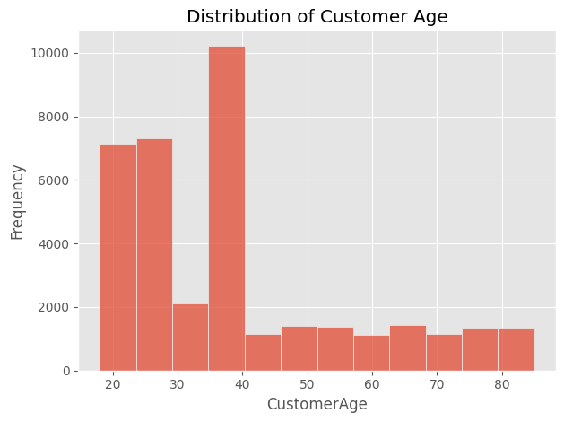

```python
sns.histplot(df, x='CustomerAge', bins=12)
plt.title('Distribution of Customer Age')
plt.ylabel('Frequency')

plt.grid(True)
plt.tight_layout()
plt.show()
```

- How does the gender distribution of customers look like?

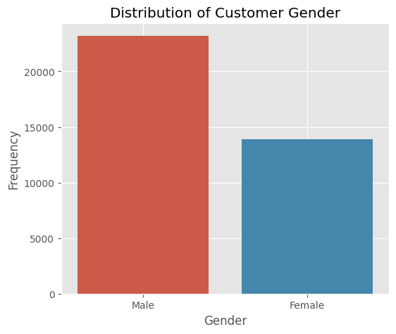

```
Gender
Male      23186
Female    13911
Name: Gender, dtype: int64
```

```python
plt.figure(figsize=(6,5))
sns.countplot(df, x='Gender')
plt.title('Distribution of Customer Gender')
plt.ylabel('Frequency')

plt.grid(True)
plt.show()

gender = df['Gender'].value_counts()
gender.name = 'Gender'
print(gender)
```

- What is the marital status distribution of customers?

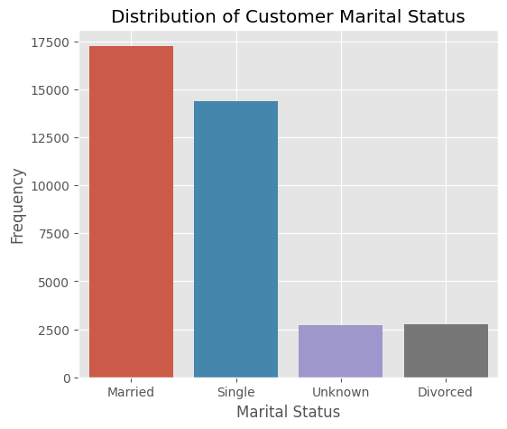

```
Marital Status
Married     17257
Single      14393
Divorced     2743
Unknown      2704
Name: Marital Status, dtype: int64
```

```python
plt.figure(figsize=(6,5))
sns.countplot(df, x='Marital Status')
plt.title('Distribution of Customer Marital Status')
plt.ylabel('Frequency')

plt.grid(True)
plt.show()

marital = df['Marital Status'].value_counts()
marital.name = 'Marital Status'
print(marital)
```

2. **Card Information:**
- What is the most common card type (e.g., Visa, Verve)?

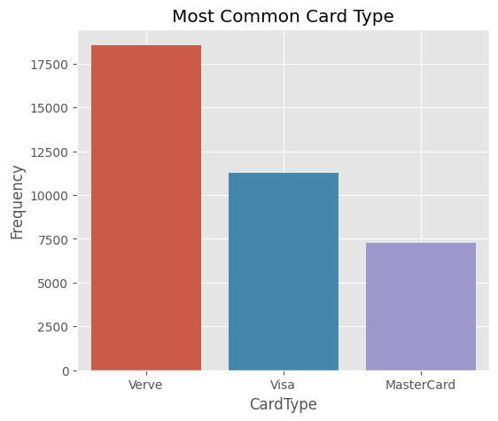

```
The most common card use is Verve with 18550 numbers
```

```python
plt.figure(figsize=(6,5))
sns.countplot(df, x='CardType')
plt.title('Most Common Card Type')
plt.ylabel('Frequency')

plt.grid(True)
plt.show()

verve = df[df['CardType'] == 'Verve'].shape[0]
print(f'The most common card use is Verve with {verve} numbers')
```

- How many credit cards vs. debit cards are there in the dataset?

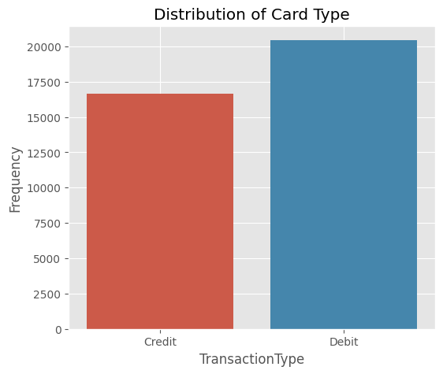

```
TransactionType
Debit     20440
Credit    16657
Name: Transaction Type, dtype: int64
```

```python
plt.figure(figsize=(6,5))
sns.countplot(df, x='TransactionType')
plt.title('Distribution of Card Type')
plt.ylabel('Frequency')

plt.grid(True)
plt.show()

credeb = df.TransactionType.value_counts()
credeb.name = 'Transaction Type'
credeb
```

- What is the most common card color?

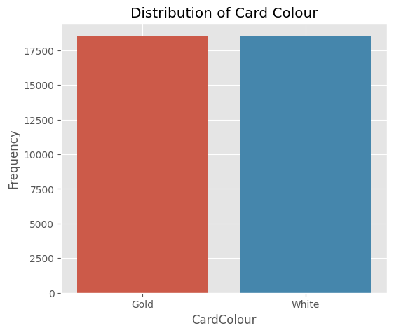

[output not shown]

```python
plt.figure(figsize=(6,5))
sns.countplot(df, x='CardColour')
plt.title('Distribution of Card Colour')
plt.ylabel('Frequency')

plt.grid(True)
plt.show()

white_col = df['CardColour'].value_counts()[0]
print(f'The most card colour used is White, with {white_col} numbers')
```

3. **Transaction Analysis:**
- What is the average transaction amount in the dataset?

```python
average_trans = df.Amount.mean()
print(f'The average Transaction amount is {int(np.ceil(average_trans))}')
```

```
The average Transaction amount is 550261
```

- Can you identify any patterns in transaction types (Credit vs. Debit) based on card type, gender, or age?

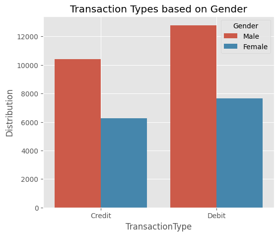

```python
plt.figure(figsize=(6,5))
sns.countplot(df, x='TransactionType', hue='Gender')

plt.title('Transaction Types based on Gender')
plt.ylabel('Distribution')
plt.grid(True)
plt.show()
```

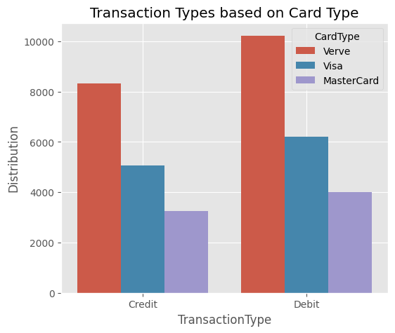

```python
plt.figure(figsize=(6,5))
sns.countplot(df, x='TransactionType', hue='CardType')

plt.title('Transaction Types based on Card Type')
plt.ylabel('Distribution')
plt.grid(True)
plt.show()
```

```python
trans_age = df.groupby('CustomerAge')['TransactionType'].value_counts().reset_index()
combine = pd.merge(trans_age[trans_age['TransactionType'] == 'Credit'],trans_age[trans_age['TransactionType'] == 'Debit'], on='CustomerAge', how='inner')
```

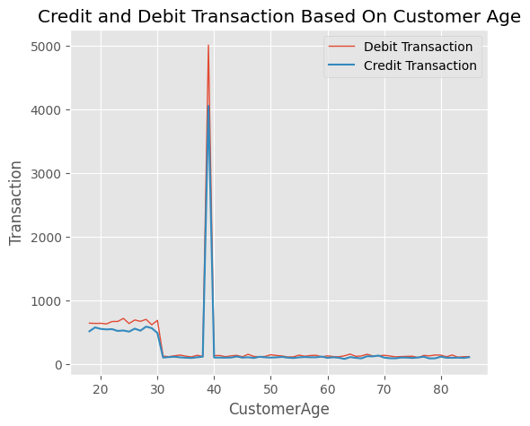

```python
plt.figure(figsize=(6,5))
sns.lineplot(combine, y='count_y', x='CustomerAge', label='Debit Transaction', linewidth=1)
sns.lineplot(combine, y='count_x', x='CustomerAge', label='Credit Transaction')


plt.ylabel('Transaction')
plt.title('Credit and Debit Transaction Based On Customer Age')
plt.show()
```

- What is the distribution of transaction outcomes (0 vs. 1)?

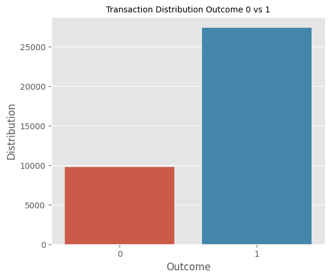

```
Outcome
1    27370
0     9727
Name: count, dtype: int64
```

```python
plt.figure(figsize=(6,5))
sns.countplot(df, x='Outcome')

plt.ylabel('Distribution')
plt.title('Transaction Distribution Outcome 0 vs 1', fontsize=10)
plt.show()


df['Outcome'].value_counts()
```

4. **Limits and Balances:**
- What are the average credit limits for different card types?

```python
card_avg_crelim = np.round(df.groupby('CardType')['CreditLimit'].mean(),2).reset_index()
card_avg_crelim.columns = ['Card Type','Avg Credit Limit']
card_avg_crelim
```

|  | Card Type | Avg Credit Limit |
| --- | --- | --- |
| 0 | MasterCard | 379553.60 |
| 1 | Verve | 334733.15 |
| 2 | Visa | 307126.41 |

- Are there any relationships between customer age and credit limits?

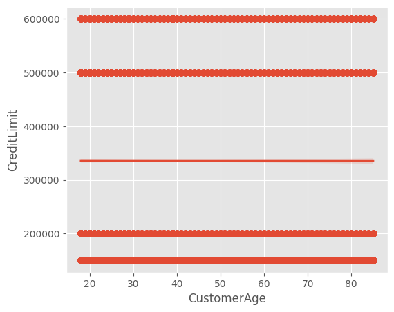

```python
plt.figure(figsize=(6,5))
sns.regplot(df,x='CustomerAge', y='CreditLimit')
plt.show()
```

- Is there a correlation between old balance and new balance?

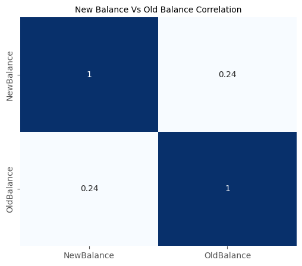

```
Correlation: 0.24
```

```python
plt.figure(figsize=(6,5))
correlation_matrix = df[['NewBalance', 'OldBalance']].corr()
sns.heatmap(correlation_matrix, annot=True, cmap='Blues', cbar=False)

plt.title('New Balance Vs Old Balance Correlation', fontsize=10)
plt.show()

print(f"Correlation: {np.round(df['NewBalance'].corr(df['OldBalance']),2)}")
```

5. **Location and Domain Analysis:**
- How are transaction types distributed across domains (e.g., Local vs. International)?

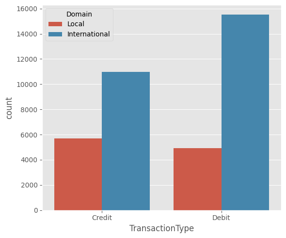

```python
plt.figure(figsize=(6,5))
sns.countplot(df, x='TransactionType', hue='Domain')
plt.tight_layout()
```

- Are there any differences in transaction outcomes between domains?

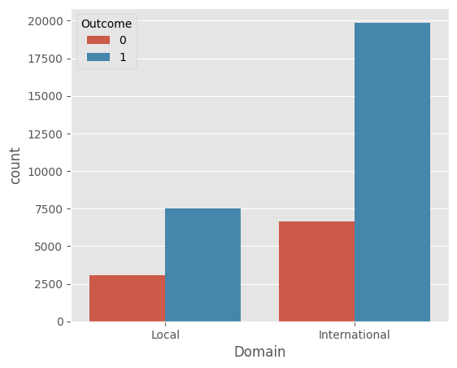

```python
plt.figure(figsize=(6,5))
sns.countplot(df, x='Domain', hue='Outcome')
plt.show()
```

6. **Income and Expenditure:**
- What is the average income expenditure of customers in the dataset?

```python
avg_incomeExp = df['AverageIncomeExpendicture'].mean()
print(f'The Average Income Expenditure by the Customers is ${np.round(avg_incomeExp, 2)}')
```

```
The Average Income Expenditure by the Customers is $227386.96
```

7. **Customer Behavior:**
- Are there any trends or patterns in transactions related to marital status?

```python
df.groupby('Marital Status')['Amount'].agg(['mean','sum'])
```

| Marital Status | mean | sum |
| --- | --- | --- |
| Divorced | 545056.120306 | 1495088938 |
| Married | 548629.347106 | 9467696643 |
| Single | 553052.450705 | 7960083923 |
| Unknown | 551095.683802 | 1490162729 |

8. **Fraud Analysis:**
- What is the proportion of fraud (Outcome=1) in the dataset?

```python
number_of_fraud = df.loc[df['Outcome'] == 1].shape[0]
total_outcomes = df.shape[0]

proportion = (number_of_fraud / total_outcomes) * 100
print(f'The proportion of fraud (Outcome=1) in the dataset is {np.round(proportion,2)}%')
```

```
The proportion of fraud (Outcome=1) in the dataset is 73.78%
```

- Can you identify any factors that may be associated with fraud cases, such as card type, transaction type, or domain?

```python
fraud_df = df.loc[df['Outcome'] == 1][['Gender','Marital Status', 'CardType', 'TransactionType','Domain']].reset_index(drop=True)
```